# A Primer to Commercial Haskell Development

Simon Meier, Digital Asset

December 1st, 2016

# This talk

Amalgamate of - A primer to commercial Haskell programming - Beginner Haskell Mistakes by Jasper van der Jeugt

Main goal: provide a launchpad for your future Haskell endeavours

# About me

- learned about Haskell during my ETH CS studies (2003)
- first "commercial" Haskell development during PhD (2007 - 2012)
- Haskell software engineer/architect at Better AG (2013 - 2014)
- post-doctoral researcher at IBM Research (2014 - 2015)
- Haskell software engineer/architect at Elevence Digital Finance AG (2015 -)

# Commercial Haskell development - my view on it

[figure not shown]

We'll want to be conscious about our business model.

See [this post-mortem of Klimpr](https://medium.com/@adriankyburz/it-s-been-an-amazing-ride-now-my-startup-is-dead-and-here-s-what-i-ve-learned-284e14ef4ee0#.w4621izgf), a friend's startup, for further insights.

# We are always selling a user experience

[figure not shown]

Haskell is just a tool in our box.

# We're only done once we've shipped our code

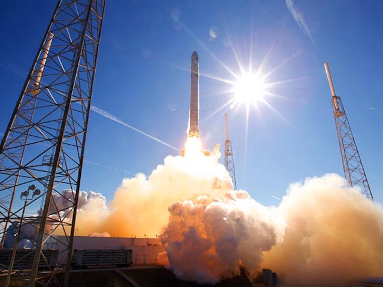

Deployment and coding are equally important.

# We want to use the right tools for the jobs at hand

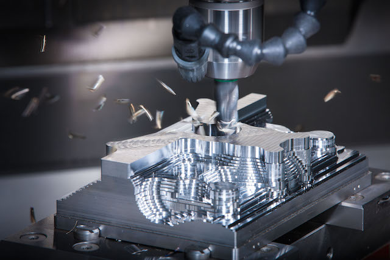

Haskell is a great tool for many software engineering tasks.

However not all problems are best solved using Haskell or FP.

# Talk Outline

- code layout
- the `stack` tool
- the custom-prelude pattern
- the .Extended-pattern
- style guidelines
- additional resources

# Code layout

Mono-repositories are great.

- transactional changes across all of your software artifacts
- see [this](http://danluu.com/monorepo/) and [that](https://github.com/babel/babel/blob/master/doc/design/monorepo.md) for more in-depth comparison of mono- vs multi-repo setups

**Big thanks to Elevence for publishing their [development repo layout](https://github.com/meiersi/HaskellerZ/tree/master/meetups/20160128-A_primer_to_commercial_Haskell_programming/code-by-elevence)** including

- their `elevence-base` library and
- their style-guide.

# The stack tool

- solid multi-library and application support
- good build reproducability
- lots of options, [which one should know about](http://docs.haskellstack.org/en/stable/GUIDE.html).

In my opinion, `stack` is a must use for commercial Haskell development.

([Nix](http://www.cse.chalmers.se/~bernardy/nix.html) is an alternative, but has a way higher ramp-up cost.)

# The custom-prelude pattern

Key purposes of our [`Elevence.Prelude`](https://github.com/meiersi/HaskellerZ/tree/master/meetups/20160128-A_primer_to_commercial_Haskell_programming/code-by-elevence/libs/hs/elevence-base/src/Elevence/Prelude.hs):

- reduce import clutter for standard modules
- provide an insulation layer against changes in GHC/Hackage
- provide a principled way of introducing orphan instances
  - introduce `Orphans.Lib_<library>` modules for defining orphan instances for classes defined in `<library>`
  - import all of these in `Elevence.Prelude`
  - guarantees instance coherence, as `Elevence.Prelude` is always in scope

I believe that every Haskell company should use their own prelude.

# The .Extended pattern

Similar goals as the custom-prelude pattern, but for individual libraries on Hackage.

- reduce import clutter
  - for libraries whose exports are too fine-grained, or
  - for functionality spread over multiple libraries (e.g., `lens` support for `text` values).
- provide an insulation layer for changes in Hackage libraries

See [Jasper Van der Jeugt's post for a detailed explanation](https://jaspervdj.be/posts/2015-01-20-haskell-design-patterns-extended-modules.html).

# The Elevence Haskell style guidelines

[Let's have a look at them](https://github.com/meiersi/HaskellerZ/blob/master/meetups/20160128-A_primer_to_commercial_Haskell_programming/code-by-elevence/docs/hs-style-guide.md).

# Additional Resources

There are a lot of resources, but they are not as condensed as one might like.

I believe Stephen Diehl's [What I wish I knew when I learned Haskell](http://dev.stephendiehl.com/hask/) provides a great entry point.

For people that are more freshly starting with Haskell, there's also our [HaskellerZ meetup repo](https://github.com/meiersi/HaskellerZ) and [my talk on getting started with Haskell](https://github.com/meiersi/HaskellerZ/blob/master/meetups/2015-02-26-Writing_your_first_real_world_Haskell_application/real_world_haskell_intro.markdown).

#Haskell: Mistakes I’ve made HaskellerZ

Jasper Van der Jeugt March 31, 2016

About me - I really like Haskell - Contributed to and authored open source projects - Did some consulting for various companies - Worked at Better, currently at fugue.co

## what this talk is about

Beginner Haskell “Mistakes” that can be avoided, signs of Haskell code smell.

## What this talk is not about

We only talk about code that is accepted by the compiler. `fib :: Int -> Int fib n = | n <= 1 = 1 | otherwise = fib (n - 1) + fib (n - 2)`

# Intro: pick your battles

Pick your battles

It’s often impossible to have perfectly clean code everywhere in large projects.

Pick your battles

- Aesthetically pleasing code?
- Just need to get the job done?
- Sacrifice clean code on the performance altar?
- Document top-level functions?

# Pick your battles What works for me: focus on modules as units.

# Pick your battles: modules The exposed interface of a module should be clean. But inside you can `unsafePerformIO` all you want.